# Lab 3 - Checkpoint 4

Marcos Nascimento (marcosantonio@copin.ufcg.edu.br)

Maio 13, 2018

# Como são as buscas no Wikimedia?

## Coleção de dados

Nossa iniciativa de investigar como são as buscas no Wikimedia iniciou realizando a coleta dos dados. Os dados foram coletados por meio do registro de logs de eventos disponibilizados pela própria Wikimedia na [internet](https://github.com/wikimedia-research/Discovery-Hiring-Analyst-2016). Primeiramente, um refinamento dos dados foi realizado com o objetivo de gerar novas variáveis que pudessem extrair algumas informações valiosas. Tais variáveis, foram utilizadas como fonte de informação para investigar as questões de pesquisa deste relatório.

```r
buscas = read_csv(here::here("data/search_data.csv")) %>%
    mutate(day=round_date(session_start_date, unit = "day"))
buscas = buscas %>%
  filter((first_click <= results) | (is.na(first_click) & num_clicks == 0))

set.seed(1)
```

## Contexto da pesquisa e questões de pesquisa

Este relatório tem como objetivo responder algumas outras questões importantes das buscas no Wikimedia. Diferentemente do relatório [anterior](http://rpubs.com/marcosasn/390792), nós agora desejamos observar como se comportam alguns resultados envolvendo testes de hipóteses levando em consideração as buscas e as navegações de buscas nas duas categorias observadas. Essa análise vai permitir identificar diferenças significativas entre os dois grupos principais de sessões de usuários.

## Resultados e discussão

**QP1:** Qual é a taxa de cliques geral diária? Como ela varia entre os grupos A e B? Existe diferença significativa da taxa de cliques geral diária entre os grupos A e B?

Com o objetivo de responder **QP1**, nós observamos como é a taxa de cliques geral diária entre os grupos. Nós observamos em um relatório anterior que essas taxas são ligeiramente diferentes. Isso fica evidente se observarmos o gráfico abaixo. Neste gráfico, é possível observar que as taxas do grupo A foram superiores, todos os dias de observação, em relação às taxas do grupo B. Com o objetivo de verificar a existência de uma diferença significativa entre essas taxas, nós utilizamos o teste de permutação de duas caldas de duas amostras. Este teste estatístico não paramétrico, avalia se duas distribuições são a mesma. Isso é feito através de permutações da variável categórica que representa o grupo da sessão de busca. Basicamente, este teste faz permutas do valor do grupo (A ou B) de modo que uma configuração base seja construída. Essa configuração base é o caso em que não podemos observar diferença significativa entre as taxas de cliques dos dois grupos. A hipótese nula do teste é que não existe diferença significativa entre as amostras, contra a hipótese alternativa que existe diferença em uma medida local, neste caso a mediana das taxas de cliques geral diária.

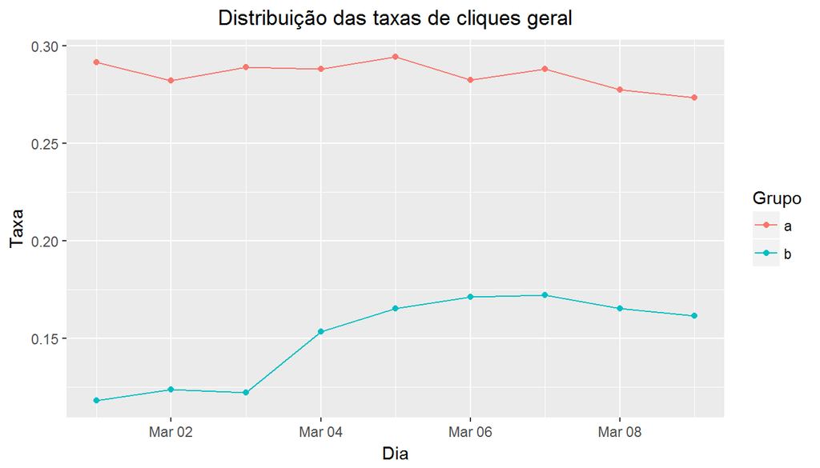

```r
buscas %>%
  group_by(day, group) %>%
  summarise(ctr_day = sum(num_clicks > 0) / n()) %>%
    ggplot(aes(x=day,
               y=ctr_day,
               color=group)) +
    geom_point() +
    geom_line() +
    labs(title="Distribuição das taxas de cliques geral", x="Dia",
         y="Taxa", color="Grupo") +
    theme(plot.title = element_text(hjust = 0.5))
```

O resultado do teste confirmou que existe uma diferença significativa entre as taxas de cliques dos grupos. Nós pudemos observar que as taxas de cliques geral diária no grupo A, em mediana, é maior que a taxa de cliques geral diária do grupo B com adequada significância estatística (p-value = 0.0012, 0.05 nível de significância). Consequentemente, isso nos permite rejeitar a hipótese nula em favor da alternativa. Este resultado corrobora com nossas conclusões em um relatório [anterior](http://rpubs.com/marcosasn/390792). Nós observamos que a distribuição da estimativa da diferença da mediana entre as taxas de cliques dos dois grupos incluia apenas números positivos maiores que zero. Como resultado disso, assim como na nossa amostra, nós pudemos notar que existia uma diferença significativa das taxas medianas de cliques geral diária entre os grupos também na população de onde os nossos dados foram coletados.

```r
#There is difference between the a diary median ctr and b (p-value=0.0012)
buscas %>%
    group_by(day, group) %>%
    summarise(ctr = sum(num_clicks > 0) / n()) %>%
    permutationTest2(median(ctr), treatment = group)
```

```
## Call:
## permutationTest2(data = ., statistic = median(ctr), treatment = group)
## Replications: 9999
## Two samples, sample sizes are 9 9
##
## Summary Statistics for the difference between samples 1 and 2:
##                   Observed          Mean Alternative PValue
## median(ctr): a-b 0.1269355 -0.0003029546   two.sided 0.0012
```

Até o momento é justo comentar sobre as vantagens e desvantagens que nós observamos entre os resultados mostrados pelo intervalo de confiança e o teste de hipótese. De modo prático, nenhuma diferença é observada com relação às conclusões. Levando em consideração o fato de que os métodos levam aos mesmos resultados. Contudo, nota-se uma diferença sutil. Nós observamos que, ambos os testes possuem desvantagens e vantagens. O intervalo de confiança, por um lado, é vantajoso porque permite conhecer o tamanho ou a extensão do *effect* do resultado. Note que, o teste aponta isso claramente através do limite superior e inferior. Contudo, como desvantagem, o mesmo exige um maior nível de abstração do leitor pela sutileza do teste. É claro, a hipótese nula do teste leva em consideração algo pouco intuitivo (a-b = 0).

Observando o teste de hipótese, por outro lado, o mesmo é vantajoso porque permite conhecer o outro lado do paraíso, a significância ou o *power* do resultado. Note que, o teste mostra isso de forma clara através do nível de confiança utilizado no teste. Além disso, neste teste, a interface exige do usuário menos esforço na comparação de grupos. Uma vez que, o pesquisador pode inserir o que será comparado de forma intuitiva. Como resultado disso, podemos observar uma menor exigência de abstração matemática do pesquisador no uso prático. Contudo, como desvantagem, percebemos um maior esforço do leitor durante a interpretação dos resultados. Principalmente, durante a leitura de artigos científicos.

**QP3:** Qual é a taxa de resultados zero geral diária? Como ela varia entre os grupos A e B? Existe diferença significativa da taxa de resultados zero geral diária entre os grupos A e B?

Com o objetivo de responder **QP3**, nós observamos como é a taxa de resultados zero geral diária entre os grupos. Nós observamos em um relatório anterior que essas taxas são ligeiramente diferentes se comparamos os grupos A e B. Isso não fica totalmente evidente se observarmos as taxas diárias no gráfico abaixo. Neste gráfico, apesar da diferença, é possível observar que as taxas de ambos os grupos se sobrepõem em vários dias de observação. Com o objetivo de verificar a existência de uma diferença significativa entre essas taxas, nós utilizados o mesmo teste utilizado em **QP1**. Neste teste em particular, o mesmo irá fazer permuta dos valores dos grupos (A ou B) de modo que uma configuração base seja construída. Essa configuração base é o caso em que não podemos observar diferença significativa entre as taxas de resultados zero geral diária entre os dois grupos.

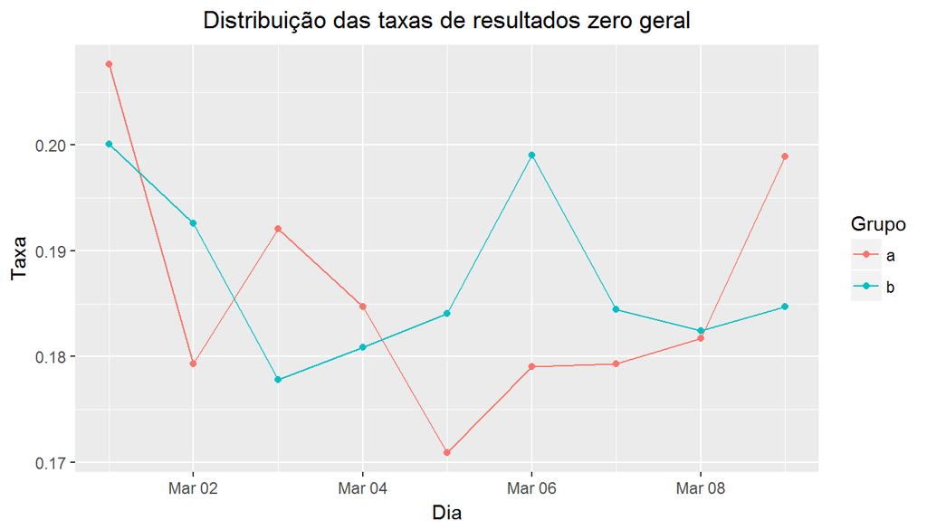

```r
buscas %>%
    group_by(day, group, results) %>%
    summarise(n = n()) %>%
    mutate(zero_ratio = n/sum(n)) %>%
    filter(results == 0) %>%
    ggplot(aes(x=day,
               y=zero_ratio,
               color=group)) +
    geom_point() +
    geom_line() +
    labs(title="Distribuição das taxas de resultados zero geral", x="Dia",
         y="Taxa", color="Grupo") +
    theme(plot.title = element_text(hjust = 0.5))
```

O resultado do teste revelou que não é possível refutar a hipótese nula em favor da alternativa (p-value = 0.3, 0.05 nível de significância). Em consequência, nós não podemos afirmar que existe uma diferença significativa entre as taxas de resultados zero geral diária entre os grupos A e B. Este resultado corrobora com nossas conclusões em um relatório anterior. Nós observamos que a distribuição da estimativa da diferença da mediana entre essas taxas entre os grupos incluia zero. Como resultado disso, não pudemos concluir que existia uma diferença significativa entre essas taxas entre os grupos.

```r
#There is no difference between a and b (p-value=0.3)
buscas %>%
    group_by(day, group, results) %>%
    summarise(n = n()) %>%
    mutate(zero_ratio = n/sum(n)) %>%
    filter(results == 0) %>%
    permutationTest2(median(zero_ratio), treatment = group)
```

```
## Call:
## permutationTest2(data = ., statistic = median(zero_ratio), treatment = group)
## Replications: 9999
## Two samples, sample sizes are 9 9
##
## Summary Statistics for the difference between samples 1 and 2:
##                             Observed          Mean Alternative PValue
## median(zero_ratio): a-b -0.002719222 -3.241954e-05   two.sided    0.3
```

Os comentários, sobre as vantagens e desvantagens que nós observamos entre os resultados mostrados pelo intervalo de confiança e o teste de hipótese, são os mesmos destacados em **QP1**. Apesar dos testes de hipótese serem extremamente relevantes por fornecer significância ou *power* do resultado, os mesmos não permitem conhecer e examinar o tamanho ou o *effect* do resultado. Assim como alguns trabalhos da literatura, nós observamos a importância de utilizar estes métodos de forma complementar.

## Conclusão

Este relatório tinha como objetivo identificar como são as buscas no Wikimedia. Nós pudemos investigar vários aspectos das buscas considerando duas categorias principais. Nós observamos que existe uma diferença significativa entre as taxas de cliques geral diária entre os grupos A e B utilizando teste de hipótese. Este achado corrobora com nossas conclusões de um relatório anterior. Quanto à proporção de buscas diárias com resultados iguais à zero, nós pudemos observar que não há evidências que apontem a existência de uma diferença significativa entre os grupos A e B. Este resultado também corrobora com nossas conclusões anteriores.